# Non-parametric tests. Anova.

Data and statistics with R Research methods

Jüri Lillemets

2019-09-26

The exercises in this task demonstrate how to plot the distribution of values and implement non-parametric tests and Analysis of variance.

# 1 Read data

Read the data on the url below. Store it in an object, e.g. `wheat`.

https://raw.githubusercontent.com/kwstat/agridat/master/data/crossa.wheat.txt

The data set contains data on a multi-environment trial of wheat for 18 genotypes at 25 locations. The variables are described as follows:

- `loc`, location
- `locgroup`, location group: Grp1-Grp2
- `gen`, genotype
- `gengroup`, genotype group: W1, W2, W3
- `yield`, grain yield, tons/ha

We are going to examine the distribution of grain yields among two location groups and three genotype groups.

# 2 Make sure you understand what the data set contains

```
## 'data.frame':    450 obs. of  5 variables:
##  $ loc     : Factor w/ 25 levels "AK","AS","BJ",..: 1 2 3 4 5 6 7 8 9 10 ...
##  $ locgroup: Factor w/ 2 levels "Grp1","Grp2": 2 1 1 2 2 2 2 1 1 1 ...
##  $ gen     : Factor w/ 18 levels "G01","G02","G03",..: 1 1 1 1 1 1 1 1 1 1 ...
##  $ gengroup: Factor w/ 3 levels "W1","W2","W3": 2 2 2 2 2 2 2 2 2 2 ...
##  $ yield   : num  6 4.1 2.7 3.5 6.9 7.8 5.2 4 3.5 4 ...
```

# 3 Add a variable

Add a variable to data frame that has the value `TRUE` when `locgroup` is “Grp1” and `FALSE` otherwise. This will make subsetting the observations easier later on as you will not need to use a condition, e.g. you will be able to use just `wheat$loc1` instead of `wheat$locgorup == 'Grp1'`.

```r
wheat$loc1 <- wheat$locgroup == 'Grp1'
head(wheat)
```

```
##   loc locgroup gen gengroup yield  loc1
## 1  AK     Grp2 G01       W2   6.0 FALSE
## 2  AS     Grp1 G01       W2   4.1  TRUE
## 3  BJ     Grp1 G01       W2   2.7  TRUE
## 4  CA     Grp2 G01       W2   3.5 FALSE
## 5  EB     Grp2 G01       W2   6.9 FALSE
## 6  EG     Grp2 G01       W2   7.8 FALSE
```

# 4 See the locations

Find out how many observations are there for each location group. Also, see which locations are included in which location groups. You can use `table()` for both of these tasks.

```
##
## Grp1 Grp2
##  288  162
```

```
##
##        AK AS BJ CA EB EG ES ID IL JM KN MG MM MS NB PA PI SC SE SG SJ SR
##   Grp1  0 18 18  0  0  0  0 18 18 18 18 18 18 18 18 18 18 18  0  0 18  0
##   Grp2 18  0  0 18 18 18 18  0  0  0  0  0  0  0  0  0  0  0 18 18  0 18
##
##        SS TB TC
##   Grp1 18  0 18
##   Grp2  0 18  0
```

You can see that the number of observations is substantially higher for the first location group. If you knew what the locations represented, the second table would help understand location groups.

# 5 Plot grain yield by location groups

First, create a boxplot to see the locations for some basic summary statistics.

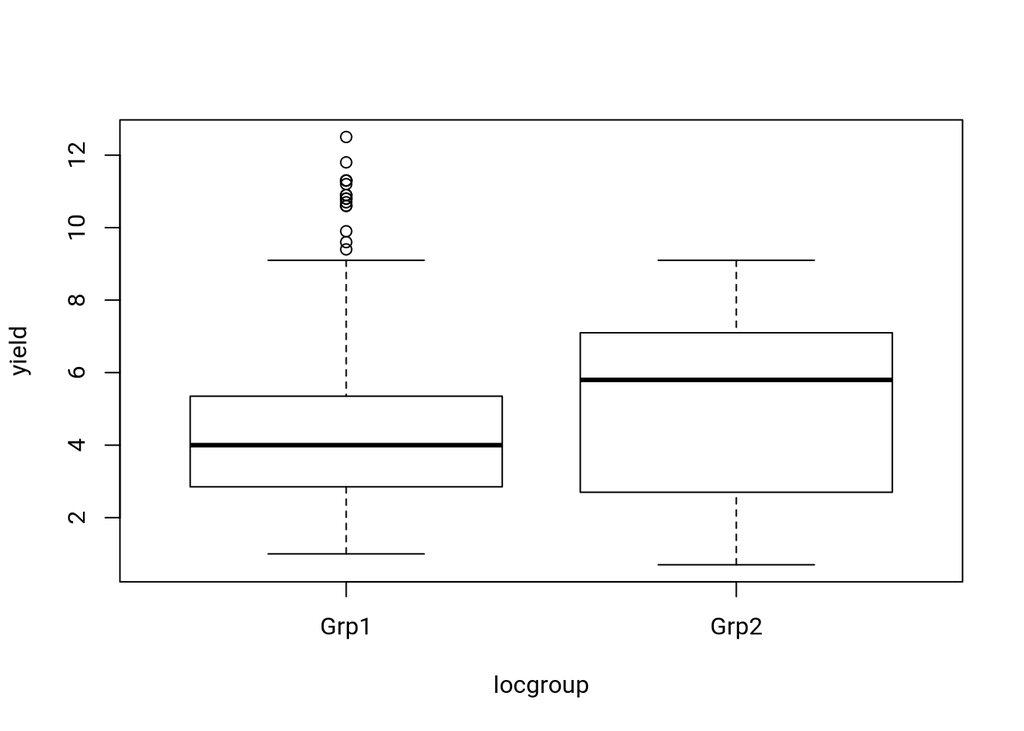

It becomes clear that yields tends to be higher for the second location group, although it is also high for some observations in the first group.

Now create two histograms, one for the values of grain yield of each location group. If you wish to have the plots side by side, you first need to run `par(mfrow = )` to set the number of rows and colums according to wich plots will be drawn.

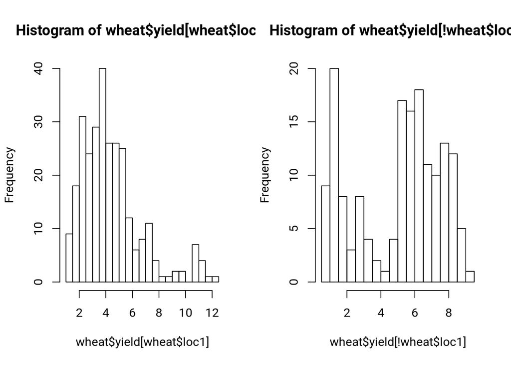

Histograms reveal the differences between the yields of two location groups much better. We can now see that while the distributions of yields of *Grp1* is just right-skewed, the distribution of *Grp2* has two peaks. Both are far from normal.

When you’re feeling adventurous, you can also try to draw both distributions on a single histogram. For this, you first need to create a histogram with all the values of grain yield and add `freq = FALSE` parameter to plot densities instead of frequencies. Then you need to add density lines with `lines(density())` with the values of both groups separately.

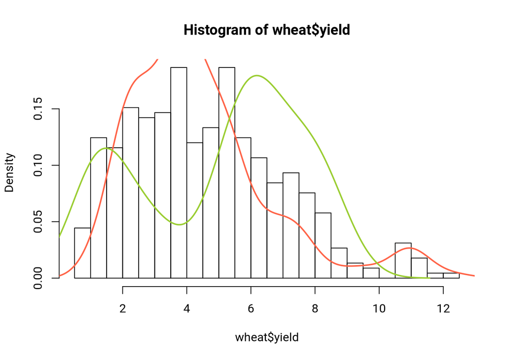

```r
hist(wheat$yield, breaks = 30, freq = F)
lines(density(wheat$yield[wheat$loc1]), col = 'tomato', lwd = 2)
lines(density(wheat$yield[!wheat$loc1]), col = 'yellowgreen', lwd = 2)
```

When completing the following excercises provide answers to the questions in R script file as comments (start line with *#*).

# 6 Does the distribution of grain yield differ among location groups?

See if the distributions of yield differs between two location groups. If you use Mann-Whitney U-test, you can specify the variables as a formula. For Kolmogorov-Smirnov test you need to pass the values of grain yield of both location groups separately to the function.

```r
wilcox.test(yield ~ loc1, wheat)
```

```
##
##  Wilcoxon rank sum test with continuity correction
##
## data:  yield by loc1
## W = 27994, p-value = 0.0004255
## alternative hypothesis: true location shift is not equal to 0
```

```r
ks.test(wheat$yield[wheat$loc1], wheat$yield[!wheat$loc1])
```

```
##
##  Two-sample Kolmogorov-Smirnov test
##
## data:  wheat$yield[wheat$loc1] and wheat$yield[!wheat$loc1]
## D = 0.36188, p-value = 3.217e-12
## alternative hypothesis: two-sided
```

# 7 Is grain yield higher in locations of first group compared to the second?

You first need to see which of the two groups is listed first, because that’s the group that will be evaluated as being *greater* or *less* than the other. Use the `unique()` to see the ordering of groups.

```r
unique(wheat$locgroup)
```

```
## [1] Grp2 Grp1
## Levels: Grp1 Grp2
```

We can see that while “Grp2” is listed as first, in factor levels “Grp1” is actually first. Test functions respect this latter ordering of factor levels. So to see if the values of first group are higher than second, you need to set the aleternative hypothesis to *greater*.

```r
wilcox.test(yield ~ locgroup, wheat, alt = 'greater')
```

```
##
##  Wilcoxon rank sum test with continuity correction
##
## data:  yield by locgroup
## W = 18662, p-value = 0.9998
## alternative hypothesis: true location shift is greater than 0
```

# 8 Are the mean yields different among genotype groups?

Next, see if mean yields are affected by genotype group. Again, start by examining how many observations are there in each group and which genotypes each group contains.

```
##
##  W1  W2  W3
## 100 225 125
```

```
##
##      G01 G02 G03 G04 G05 G06 G07 G08 G09 G10 G11 G12 G13 G14 G15 G16 G17
##   W1   0   0   0  25  25   0  25   0  25   0   0   0   0   0   0   0   0
##   W2  25  25   0   0   0  25   0   0   0  25   0  25   0  25   0  25  25
##   W3   0   0  25   0   0   0   0  25   0   0  25   0  25   0  25   0   0
##
##      G18
##   W1   0
##   W2  25
##   W3   0
```

There are three groups, so we need to use Anova to test differences in means among groups. Find out the mean values of yield for each genotype group. You can use `aggregate()` to do that.

```
##   gengroup    yield
## 1       W1 4.922000
## 2       W2 4.664444
## 3       W3 4.420000
```

Differences in means are quite negligible.

If you recall, Anova procedure also takes into account indidual values. Plot genotype group against grain yields. If you use `plot()`, it automatically creates a boxplot, because `gengroup` is a variable of type factor. That’s alright, since we can still see how individual values are distributed.

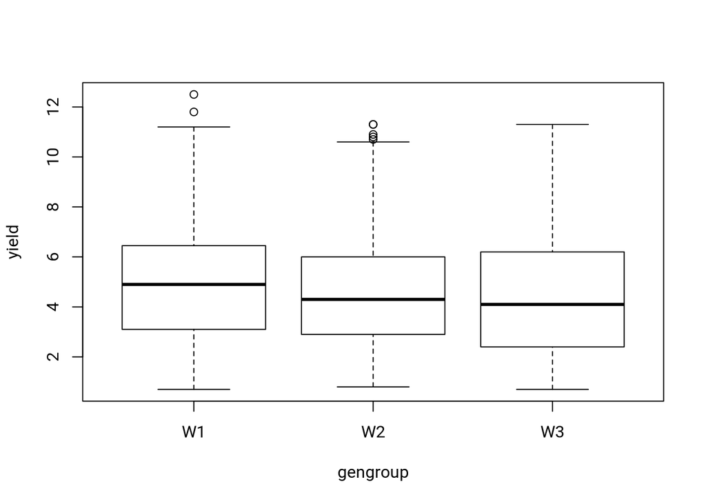

The values seem to be more or less normally distributed. Now apply Anova to see if the differences in means are statistically significant.

```r
summary(aov(yield ~ gengroup, wheat))
```

```
##              Df Sum Sq Mean Sq F value Pr(>F)
## gengroup      2   14.1   7.026   1.253  0.287
## Residuals   447 2506.0   5.606
```

Once you learn how to apply methods here you will be able to do hypothesis testing on non-normal data and apply Anova when there are more than two groups.